# High School Seniors t Test

**Week 3 Analysis**

```r
library(tidyverse)
library(DT)
library(pander)
library(readr)
library(car)

HSS <- read_csv("../../Data/HighSchoolSeniors.csv")
View(HSS)
```

## Background

There is a common belief that boys and girls have different heights, with boys usually being taller. This study uses data from 500 high school seniors in the United States to test this belief. We will focus on comparing the heights of boys and girls. The question we want to answer is:

**Is there a significant difference in height between boys and girls?**

We will use an Independent Samples t-test for this analysis.

### Question

Is there a significant difference in height between boys and girls?

For this study, we will compare the heights of male and female participants based on the data collected.

We will use an Independent Samples t-test with the following hypotheses:

**Null Hypothesis (H₀):** The average height of boys and girls is the same.

$$H_0: \mu_\text{Boys} - \mu_\text{Girls} = 0$$
This means that there is no difference in mean height between boys and girls.

**Alternative Hypothesis (H₁):** The average height of boys and girls is different

$$H_a: \mu_\text{Boys} - \mu_\text{Girls} \neq 0$$
This means there is a significant difference in mean height between boys and girls.

```r
t.test(Height_cm ~ Gender, data = HSS, mu = 0, alternative = "two.sided")
```

```
##
##  Welch Two Sample t-test
##
## data:  Height_cm by Gender
## t = -4.6575, df = 323.88, p-value = 4.679e-06
## alternative hypothesis: true difference in means between group Female and group Male is not equal to 0
## 95 percent confidence interval:
##  -32.73113 -13.29135
## sample estimates:
## mean in group Female   mean in group Male
##             156.4317             179.4430
```

### QQ Plot

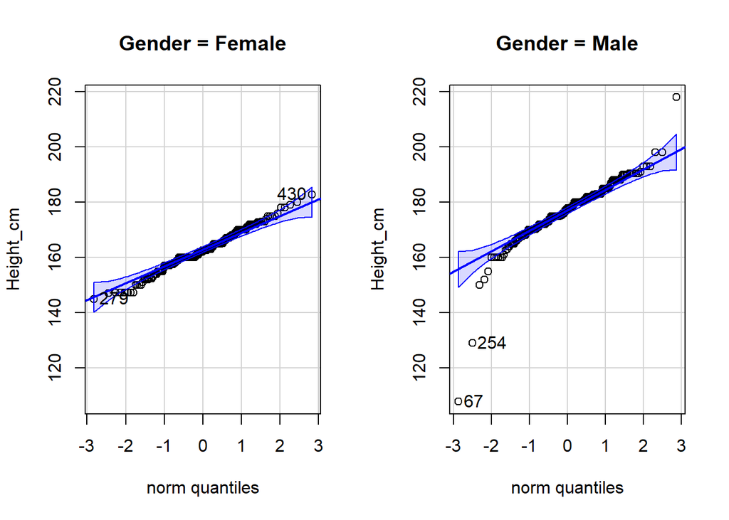

```r
HSS_filtered <- HSS[HSS$Height_cm >= 100 & HSS$Height_cm <= 250 & !is.na(HSS$Height_cm) &        !is.na(HSS$Gender), ]

qqPlot(Height_cm ~ Gender, data = HSS_filtered, main = "Q-Q Plot of Height by Gender (100-250 cm)")
```

### Boxplot

The boxplot shows that boys tend to be taller than girls, just like the results from the t-test. The plot clearly displays the difference in height between genders.

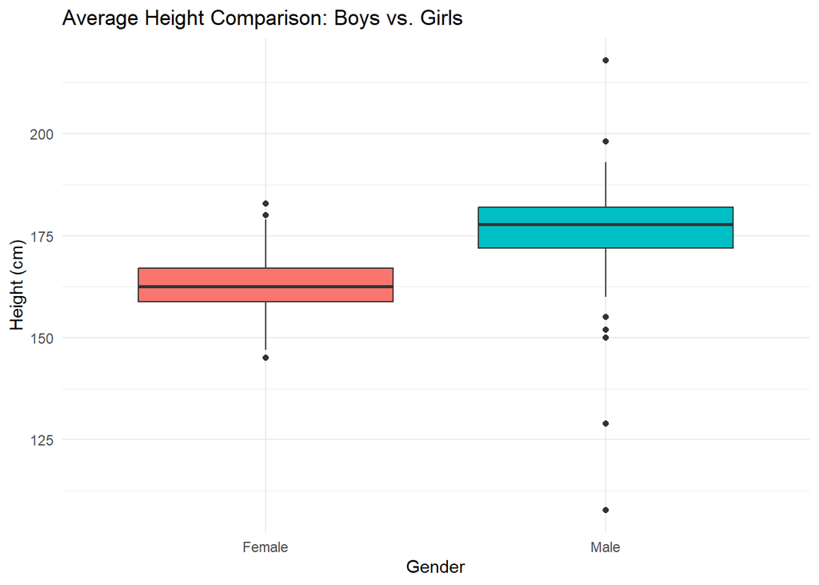

```r
ggplot(HSS_filtered, aes(x = Gender, y = Height_cm, fill = Gender)) +
  geom_boxplot() +
  labs(title = "Average Height Comparison: Boys vs. Girls",
       x = "Gender",
       y = "Height (cm)") +
  theme_minimal() +
  theme(legend.position = "none")
```

### Conclusion

The results of the t-test strongly suggest that there is a significant difference in height between boys and girls, with boys being taller. We can confidently reject the idea that there is no difference in height. The confidence interval for the height difference shows that boys are, on average, between **13.29 cm and 32.73 cm** taller than girls. The results are consistent across different plots (QQ plot and boxplot), which helps confirm the findings. Future research could look at other factors that might affect height, such as genetics or nutrition, to give a broader understanding of why this difference exists.